# Dashboard for BirdLife LitScan processing

Bill Oxbury

2023-02-22

*This file is updated automatically as part of the scanner processing.*

### First statistics

The [BlitScan app](https://blitscanapp.azurewebsites.net/) is built over a data set of journal articles/research publications:

```
## Number of articles: 96,052
```

```
## Number of species: 9,405
```

```
## Number of journals/proceedings: 5,075
```

```
## Number of publishers: 1,779
```

More detail on journals and publishers is given below. A full list of journals/proceedings the database draws from is given in the appendix.

### Species coverage

The counts in the table below are the numbers of species (normalised to *SISRecID* identifier and classified by red-list status) referenced in the database, versus those occurring in the [BirdLife DataZone](http://datazone.birdlife.org/home).

| Status | Count | OutOf | Percent |
| --- | --- | --- | --- |
| LC | 6,156 | 8,771 | 70.2 |
| unknown | 1,442 | 2,027 | 71.1 |
| NR | 1,423 | 2,004 | 71.0 |
| NT | 760 | 1,084 | 70.1 |
| VU | 637 | 824 | 77.3 |
| EN | 374 | 463 | 80.8 |
| CR | 186 | 213 | 87.3 |
| EX | 89 | 164 | 54.3 |
| DD | 28 | 50 | 56.0 |
| CR (PE) | 14 | 22 | 63.6 |
| PE | 14 | 22 | 63.6 |
| EW | 5 | 5 | 100.0 |

How many journal articles are we seeing per-species? (Each ‘dot’ below is a species. We emphasise this by labelling the top-represented species in each group.)

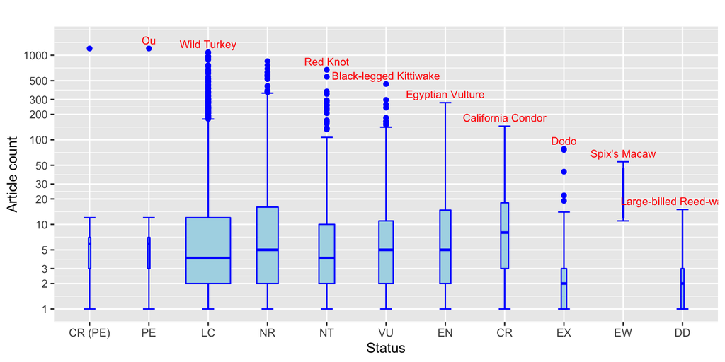

### Sources

The search process to find web content follows four main steps to identify articles, followed by text retrieval from those articles. These are:

1. Bing Custom Search against targeted domains
2. Querying preprint archives
3. Querying open data aggregators [OpenAlex](https://openalex.org/) and [Open Archives Initiative (OAI)](http://www.openarchives.org/OAI/openarchivesprotocol.html)
4. Scanning of content lists for targeted journals.

#### Step 1: [Custom Search](https://docs.microsoft.com/en-us/bing/search-apis/bing-custom-search/overview)

This first step uses the full power of customised web search - previously using Google, now using Microsoft Bing. It gives us a wide reach, while the journal scans in the later steps help ensure completeness.

The process manages the cost of search by sampling search terms at each run, with the aim of achieving repeated coverage of all search terms over time. Custom search runs queries against a set of targeted domains (which will be listed below after describing steps 2,3,4). The queries cycle stochastically through species names. (Currently scientific names only, but that is configurable.)

URLs returned from this process are stored and mined individually *after* all of steps 1-4 have completed.

#### Step 2: preprint archives

Similar to step 1, except that instead of using a commercial search engine, queries are made directly to a set of preprint archives, currently consisting of:

| Archive | Language | URL | Count |
| --- | --- | --- | --- |
| bioRxiv | en | https://www.biorxiv.org/search/search_term | 3,858 |
| J-Stage | ja | https://www.jstage.jst.go.jp/result/global/-char/ja?globalSearchKey=search_term | 3,180 |

URLs returned from this process are stored and mined individually after all of steps 1-4 have completed.

#### Step 3: [OpenAlex](https://openalex.org/) and [OAI](http://www.openarchives.org/OAI/openarchivesprotocol.html)

These are centralised services that collect research metadata, including titles/abstracts, from institutions and publishers around the world. On the one hand, they protect providers from cyber threats if they permit web crawling directly to their servers; on the other hand, they greatly simplify the process for data consumers by providing a single format across a very wide community of providers.

As of June 2022 there are 5,616 listed providers to OAI. Most of these are not relevant to conservation biology, and we are currently using OAI for access to just one provider [BioOne](https://bioone.org). Journals published by BioOne that we’re using as relevant to BirdLife are the following. (The count is the number of articles, from OAI access, currently in the BlitScan database.)

| Journal | Society | Publisher | Count |
| --- | --- | --- | --- |
| Zoological Science | Zoological Society of Japan | Zoological Society of Japan | 227 |
| Wildlife Biology | Nordic Board for Wildlife Research | Wiley | 202 |
| The Southwestern Naturalist | Southwestern Association of Naturalists | Southwestern Association of Naturalists | 182 |
| African Zoology | Zoological Society of Southern Africa | Informa UK Limited | 158 |
| Ardeola | Spanish Society of Ornithology | Ardeola | 114 |
| The Wilson Journal of Ornithology | The Wilson Ornithological Society | Wilson Ornithological Society | 109 |
| Waterbirds | The Waterbird Society | Waterbird Society | 98 |
| Ornithological Science | The Ornithological Society of Japan | Ornithological Society of Japan | 93 |
| Ardea | Netherlands Ornithologists’ Union | Netherlands Ornithologists’ Union | 89 |
| Bulletin of the British Ornithologists’ Club | British Ornithologists’ Club | British Ornithologists’ Club | 76 |
| Bulletin of the British Ornithologists’ Club | British Ornithologists’ Club | British Ornithologists’ Club | 76 |
| The Auk | American Ornithological Society | Oxford University Press (OUP) | 74 |
| Ornithology | American Ornithological Society | Oxford University Press (OUP) | 74 |
| Journal of Raptor Research | Raptor Research Foundation | The Raptor Research Foundation, Inc. | 50 |
| Journal of East African Natural History | Nature Kenya/East African Natural History Society | East African Natural History Society | 30 |
| NA | Finnish Zoological and Botanical Publishing Board | NA | 16 |
| NA | Society for Vector Ecology | NA | 14 |
| NA | Muséum national d’Histoire naturelle, Paris | NA | 12 |
| NA | Beta Beta Beta Biological Society | NA | 10 |
| NA | Stuttgart State Museum of Natural History | NA | 10 |
| NA | American Museum of Natural History | NA | 7 |
| NA | Biological Society of Washington | NA | 3 |
| NA | Southern California Academy of Sciences | NA | 2 |

OpenAlex is more recent, launching in early 2022 but claiming [100M’s of documents across a wide range of sources](https://docs.openalex.org/about-the-data-1). From OpenAlex the BlitScan database links to:

| DocType | Count |
| --- | --- |
| journal-article | 69,590 |
| NA | 11,700 |
| dissertation | 2,327 |
| posted-content | 1,769 |
| book-chapter | 1,065 |
| proceedings-article | 509 |
| dataset | 269 |
| book | 187 |
| report | 99 |
| component | 43 |
| monograph | 36 |
| peer-review | 30 |
| reference-entry | 27 |
| other | 22 |
| journal-issue | 11 |
| reference-book | 5 |
| report-series | 2 |
| book-part | 1 |
| grant | 1 |
| standard | 1 |

#### Step 4: journal contents listings

This step explicitly scans the tables of contents for recent issues of key journals. Those currently scanned are the following.

| Journal | Language | URL | Count |
| --- | --- | --- | --- |
| Conservation Science & Practice | en | https://conbio.onlinelibrary.wiley.com/journal/25784854 | 494 |
| Conservation Biology | en | https://conbio.onlinelibrary.wiley.com/journal/15231739 | 468 |
| PLOS ONE | en | https://journals.plos.org/plosone/browse/ | 424 |
| Oryx | en | https://www.cambridge.org/core/journals/oryx/all-issues | 312 |
| Conservation Letters | en | https://conbio.onlinelibrary.wiley.com/journal/1755263x | 216 |
| Journal of Ornithology | en | https://www.springer.com/journal/10336 | 108 |
| Ornitologia Neotropica | es | https://journals.sfu.ca/ornneo/index.php/ornneo/issue/archive | 92 |
| Avian Conservation & Ecology | fr | https://www.ace-eco.org | 83 |
| Emu - Austral Ornithology | en | https://www.tandfonline.com/toc/temu20/current | 81 |
| Bird Conservation International | en | https://cambridge.org/core/journals/bird-conservation-international | 46 |
| Ornitología Colombiana | es | https://asociacioncolombianadeornitologia.org/revista-ornitologia-colombiana/ | 33 |
| Ostrich - Journal of African Ornithology | en | https://www.nisc.co.za/products/11/journals/ostrich-journal-of-african-ornithology | 26 |
| Bird Study | en | https://www.tandfonline.com/toc/tbis20/current | 18 |
| Avian Research | en | https://avianres.biomedcentral.com | 2 |

#### Step 1 revisited - domains and issues arising

The initial custom search covers many more journals than those visited in steps 2-4 (see the appendix). This is possible by running searches against *domains* rather than individual journals or even publishers:

| Domain | Minable? | Count |
| --- | --- | --- |
| biorxiv.org | 1 | 4,010 |
| jstage.jst.go.jp | 1 | 3,195 |
| conbio.onlinelibrary.wiley.com | 0 | 1,283 |
| journals.plos.org | 1 | 1,204 |
| link.springer.com | 1 | 1,039 |
| cambridge.org | 1 | 847 |
| nature.com | 1 | 644 |
| sciencedirect.com | 0 | 493 |
| ace-eco.org | 1 | 460 |
| tandfonline.com | 1 | 430 |
| avianres.biomedcentral.com | 1 | 186 |
| nisc.co.za | 1 | 176 |
| journals.sfu.ca | 1 | 144 |
| asociacioncolombianadeornitologia.org | 1 | 60 |
| orientalbirdclub.org | 1 | 56 |
| int-res.com | 1 | 31 |
| sciendo.com | 1 | 23 |
| academic.oup.com | 0 | 20 |
| birdlife.org.au | 1 | 0 |
| mexorn.org | 1 | 0 |
| hilarispublisher.com | 0 | 0 |
| mdpi.com | 0 | 0 |
| omicsonline.org | 0 | 0 |
| meridian.allenpress.com | 0 | 0 |

The binary indicator ‘minable’ refers to domain policy which in some cases (minable = 0) prohibits or limits text extraction later on. Notable examples are *conbio.onlinelibrary.wiley.com* and *academic.oup.com*. In some cases we are able to work with these domains via open archive initiatives.

### Language coverage

We aim to grow the coverage of non-English language sources by taking advantage of cloud translation services. The current distribution of languages represented in the BlitScan database is shown below. ([See here for the language codes.](https://en.wikipedia.org/wiki/List_of_ISO_639-1_codes))

| language | Count | OutOf |
| --- | --- | --- |
| en | 84,159 | 90,199 |
| es | 3,718 | 3,806 |
| ja | 2,686 | 6,549 |
| pt | 1,531 | 1,534 |
| fr | 1,444 | 1,466 |
| id | 665 | 686 |
| de | 272 | 324 |
| ko | 207 | 235 |
| ru | 153 | 158 |
| pl | 132 | 140 |
| ca | 96 | 100 |
| tr | 92 | 103 |
| hr | 90 | 97 |
| it | 87 | 107 |
| nl | 72 | 74 |
| zh-Hans | 59 | 60 |
| fa | 58 | 59 |
| cs | 54 | 67 |
| hu | 47 | 49 |
| sl | 43 | 44 |
| sv | 43 | 45 |
| ro | 35 | 38 |
| uk | 31 | 33 |
| et | 30 | 41 |
| nb | 19 | 19 |
| es\|pt | 18 | 18 |
| es\|ca | 13 | 13 |
| es\|fr | 13 | 13 |
| el | 12 | 12 |
| gl | 11 | 11 |

[output cut: 67 more lines]

In this table, ‘Count’ refers to the current database while ‘OutOf’ refers to the wider data set of articles that is stored before filtering down to the database used. Filtering is based on both date and relevance.

Conservation relevance (see section ‘score distribution’ below):

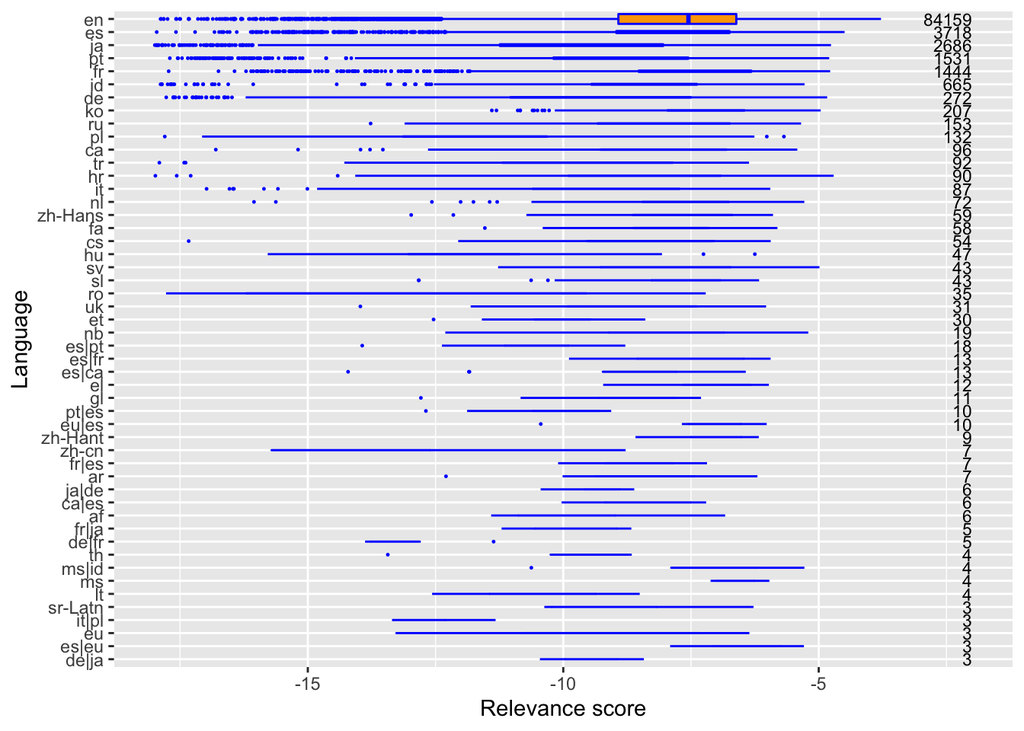

### Date range

The range and distribution of known dates of articles in the database:

```
## Date range 1995-08-01 to 2023-02-20
```

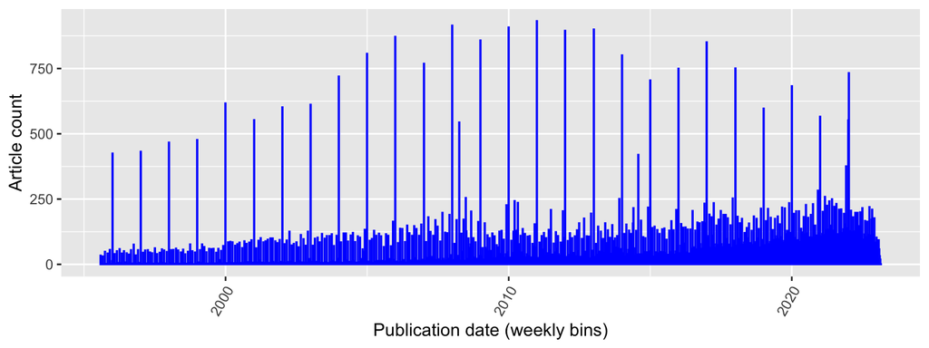

Note that points beyond today’s date usually indicate instances where publication comes later than online announcement.

Reading of dates can be a fallible process - how well are we able to parse publication dates for URLs?

```
## Proportion of records with date parsed: 99.8%
```

By domain this looks like:

```
##
## domain                                  FALSE  TRUE
##                                           129 76905
##   academic.oup.com                          5    15
##   ace-eco.org                               1   523
##   asociacioncolombianadeornitologia.org     1    59
##   avianres.biomedcentral.com                1   185
##   bioone.org                                2  1605
##   biorxiv.org                               9  4248
##   cambridge.org                             2  1375
##   complete.bioone.org                      14    11
##   conbio.onlinelibrary.wiley.com            0  1283
##   doi.org                                   2  1119
##   int-res.com                               2    90
##   journals.plos.org                         0  1204
##   journals.sfu.ca                           0   144
##   jstage.jst.go.jp                          5  3230
##   link.springer.com                         0  1039
##   local                                     0    96
##   mexorn.org                                0     2
##   nature.com                               21  1208
##   nisc.co.za                                2   475
##   orientalbirdclub.org                     15    67
##   sciencedirect.com                         1   492
##   sciendo.com                               0    35
##   tandfonline.com                           1   429
```

### Score distribution

Text retrieved is scored in the downstream *process* stage. Here is the overall distribution, with the quartiles/median marked in red.

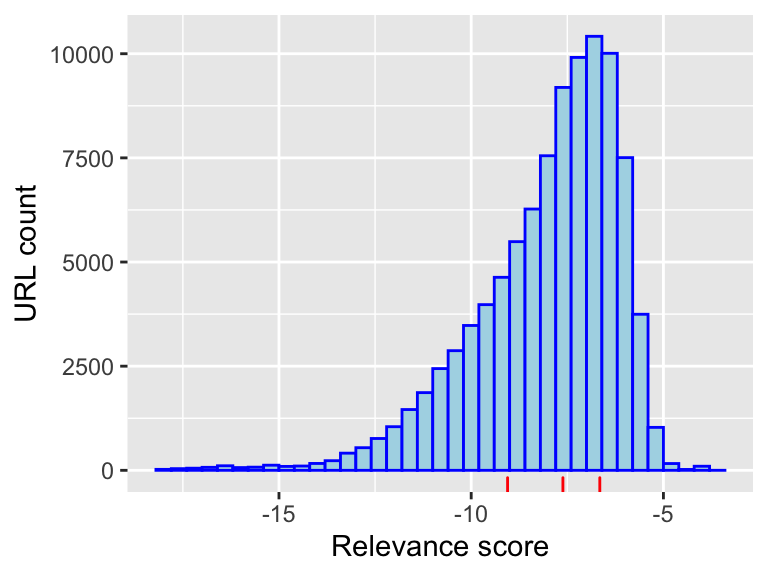

This score then provides a basis for comparing domains. (Note that the red quartile markers are those for the overall distribution and are the same for all subplots.) For clarity we only show domains exceeding a count threshold:

```
## Count threshold for plot:  30
```

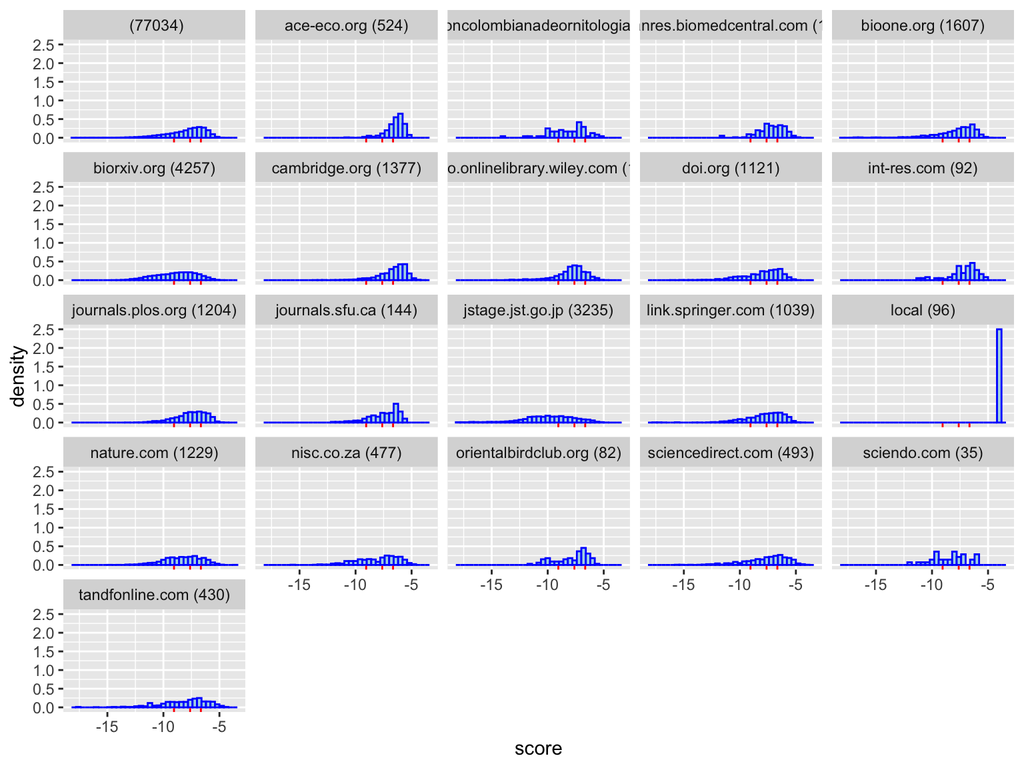

One can make some observations from this plot. For each domain, a skew to the right is good, to the left is not good.

Second, the profile for *biorxiv.org* is less strong and could suggest a review of how the site is crawled.

Third, bimodal distributions (i.e. showing outlying lumps to the left) can indicate non-English text that has not yet been translated.

Finally, a visual check on *link.springer.com* is useful just because Springer turns out to dominate the journals visited by the custom search (step 1). (See the appendix.)

### Text retrieval

All of the above statistics refer to articles in the Blitscan database for which text has been successfully retrieved. But that represents a subset of a larger dataset of URLs (coming from steps 1-4 above) for which text retrieval was attempted. Here we summarise the success or not, by domain, of text retrieval on this fuller dataset.

We’ve indicated above (‘Step 1 revisited’) that not all domains consistently permit web crawling. Among responsive domains, the following counts show URLs from which text was retrieved:

| Domain | GotText | OutOf | Percent |
| --- | --- | --- | --- |
|  | 77,365 | 77,414 | 99.9 |
| jstage.jst.go.jp | 8,369 | 31,933 | 26.2 |
| link.springer.com | 4,364 | 7,175 | 60.8 |
| biorxiv.org | 4,317 | 4,323 | 99.9 |
| cambridge.org | 2,149 | 2,846 | 75.5 |
| bioone.org | 1,610 | 11,119 | 14.5 |
| nature.com | 1,421 | 1,508 | 94.2 |
| conbio.onlinelibrary.wiley.com | 1,308 | 2,475 | 52.8 |
| journals.plos.org | 1,232 | 1,236 | 99.7 |
| doi.org | 1,122 | 1,122 | 100.0 |
| ace-eco.org | 541 | 741 | 73.0 |
| sciencedirect.com | 493 | 2,985 | 16.5 |
| nisc.co.za | 481 | 482 | 99.8 |
| tandfonline.com | 437 | 833 | 52.5 |
| avianres.biomedcentral.com | 399 | 407 | 98.0 |
| journals.sfu.ca | 172 | 315 | 54.6 |
| asociacioncolombianadeornitologia.org | 158 | 196 | 80.6 |
| int-res.com | 145 | 146 | 99.3 |
| local | 97 | 97 | 100.0 |
| orientalbirdclub.org | 82 | 82 | 100.0 |
| sciendo.com | 52 | 52 | 100.0 |
| complete.bioone.org | 25 | 1,560 | 1.6 |
| academic.oup.com | 20 | 715 | 2.8 |
| mexorn.org | 20 | 24 | 83.3 |

Where possible, text is harvested from PDFs as well as HTML. The following are the current PDF counts in the database, by domain:

| Domain | PDF |
| --- | --- |
| biorxiv.org | 4,150 |
| jstage.jst.go.jp | 2,850 |
| cambridge.org | 1,366 |
| conbio.onlinelibrary.wiley.com | 1,283 |
| journals.plos.org | 1,201 |
| nature.com | 1,048 |
| link.springer.com | 1,039 |
| ace-eco.org | 522 |
| avianres.biomedcentral.com | 186 |
| journals.sfu.ca | 143 |
| local | 96 |
| int-res.com | 92 |
| sciendo.com | 35 |
| asociacioncolombianadeornitologia.org | 24 |
|  | 3 |

### Appendix: list of all journals/proceedings

The listing below makes use of the open source project [CrossRef](https://www.crossref.org/). At each of the steps in the *scrape* process we record the [Digital Object Identifier (DOI)](https://www.doi.org/) of each article if possible.

```
## Proportion of articles with known DOI: 78.124%
```

CrossRef then allows us to query all of the known DOIs in the Blitscan database to obtain a rich set of metadata. The list below is extracted from that set:

Journal

Publisher

Count

Ibis

Wiley

1508

The Condor

Oxford University Press (OUP)

1298

PLOS ONE

Public Library of Science (PLoS)

1255

The Wilson Journal of Ornithology

Wilson Ornithological Society

1189

The Auk

Oxford University Press (OUP)

1182

Animal Behaviour

Elsevier BV

932

Waterbirds

Waterbird Society

863

Journal of Avian Biology

Wiley

768

Scientific Reports

Springer Science and Business Media LLC

709

Conservation Biology

Wiley

662

CABI Compendium

CABI Publishing

625

Biological Conservation

Elsevier BV

595

Emu - Austral Ornithology

Informa UK Limited

530

Behavioral Ecology

Oxford University Press (OUP)

520

Conservation Science and Practice

Wiley

503

PLoS ONE

Public Library of Science (PLoS)

499

Journal of Raptor Research

The Raptor Research Foundation, Inc.

464

Canadian Journal of Zoology

Canadian Science Publishing

457

Ecology and Evolution

Wiley

451

Proceedings of the Royal Society B: Biological Sciences

The Royal Society

449

Journal of Avian Medicine and Surgery

Association of Avian Veterinarians (AAV)

434

Journal of Experimental Biology

The Company of Biologists

431

Bird Study

Informa UK Limited

403

Bird Conservation International

Cambridge University Press (CUP)

400

Zootaxa

Magnolia Press

392

Journal of Wildlife Diseases

Wildlife Disease Association

382

Molecular Ecology

Wiley

378

Ethology

Wiley

361

Journal of Animal Ecology

Wiley

360

Oryx

Cambridge University Press (CUP)

360

Wildlife Biology

Wiley

354

Journal of Ornithology

Springer Science and Business Media LLC

322

Ostrich

National Inquiry Services Center (NISC)

313

Molecular Phylogenetics and Evolution

Elsevier BV

310

The Wilson Bulletin

Wilson Ornithological Society

310

The Southwestern Naturalist

Southwestern Association of Naturalists

296

Journal of Field Ornithology

Resilience Alliance, Inc.

295

Marine Ecology Progress Series

Inter-Research Science Center

295

Zoological Science

Zoological Society of Japan

283

The Journal of Wildlife Management

Wiley

265

Ecology

Wiley

258

Ardea

Netherlands Ornithologists’ Union

255

Science of The Total Environment

Elsevier BV

255

Journal of Wildlife Management

Wiley

251

Journal of the Yamashina Institute for Ornithology

Yamashina Institute for Ornithology

243

Avian Conservation and Ecology

Resilience Alliance, Inc.

242

Journal of Applied Ecology

Wiley

233

General and Comparative Endocrinology

Elsevier BV

228

Conservation Letters

Wiley

227

Biology Letters

The Royal Society

226

The Journal of Wildlife Management

JSTOR

220

Journal of Zoo and Wildlife Medicine

American Association of Zoo Veterinarians

219

Behaviour

Brill

218

Journal of Parasitology

American Society of Parasitologists

218

Environmental Toxicology and Chemistry

Wiley

210

Wildlife Society Bulletin

Wiley

208

Forest Ecology and Management

Elsevier BV

203

Ornithological Science

Ornithological Society of Japan

198

Journal of Field Ornithology

Association of Field Ornithologists

195

Japanese Journal of Ornithology

JStage (Ornithological Society of Japan)

195

Environmental Pollution

Elsevier BV

191

Ardeola

Ardeola

181

Proceedings of the Royal Society of London. Series B: Biological Sciences

The Royal Society

179

PeerJ

PeerJ

176

Evolution

Wiley

171

African Zoology

Informa UK Limited

170

Journal of Evolutionary Biology

Wiley

168

Ecological Applications

Wiley

166

Acta Ornithologica

Museum and Institute of Zoology at the Polish Academy of Sciences

163

Avian Diseases

American Association of Avian Pathologists (AAAP)

163

Ostrich

Informa UK Limited

161

Ringing &amp; Migration

Informa UK Limited

157

Nature Communications

Springer Science and Business Media LLC

157

Mitochondrial DNA Part B

Informa UK Limited

157

Frontiers in Ecology and Evolution

Frontiers Media SA

155

Animal Conservation

Wiley

152

Behavioural Processes

Elsevier BV

151

Oikos

Wiley

151

Physiological and Biochemical Zoology

University of Chicago Press

146

Hormones and Behavior

Elsevier BV

146

Biological Journal of the Linnean Society

Oxford University Press (OUP)

145

The Canadian Field-Naturalist

Ottawa Field-Naturalists’ Club

143

Australian Field Ornithology

BirdLife Australia, Ltd.

142

Behavioral Ecology and Sociobiology

Springer Science and Business Media LLC

142

Journal of Zoology

Wiley

137

Southeastern Naturalist

Humboldt Field Research Institute

135

Huitzil Revista Mexicana de Ornitología

Sociedad para el Estudio y Conservacion de las Aves en Mexico A.C.

135

Nature

Springer Science and Business Media LLC

134

The American Naturalist

University of Chicago Press

132

Polar Biology

Springer Science and Business Media LLC

130

Marine Pollution Bulletin

Elsevier BV

128

Wildlife Research

CSIRO Publishing

126

Functional Ecology

Wiley

122

Current Zoology

Oxford University Press (OUP)

120

Waterbirds: The International Journal of Waterbird Biology

JSTOR

117

Avian Biology Research

SAGE Publications

117

Medical Entomology and Zoology

Japan Society of Medical Entomology and Zoology

115

Proceedings of the National Academy of Sciences

Proceedings of the National Academy of Sciences

115

Northeastern Naturalist

Humboldt Field Research Institute

112

Comparative Biochemistry and Physiology Part A: Molecular &amp; Integrative Physiology

Elsevier BV

108

Journal of Biogeography

Wiley

106

The Journal of the Acoustical Society of America

Acoustical Society of America (ASA)

105

Oecologia

Springer Science and Business Media LLC

104

Animals

MDPI AG

102

Molecular Ecology Notes

Wiley

102

Avian Research

Elsevier BV

100

Austral Ecology

Wiley

98

Molecular Ecology Resources

Wiley

97

Journal of Threatened Taxa

Wildlife Information Liaison Development Society

97

Ecological Modelling

Elsevier BV

95

Ecosphere

Wiley

94

The American Midland Naturalist

University of Notre Dame

94

Avian Pathology

Informa UK Limited

94

Royal Society Open Science

The Royal Society

92

Environmental Science &amp; Technology

American Chemical Society (ACS)

91

New Zealand Journal of Zoology

Informa UK Limited

91

CYTOLOGIA

International Society of Cytology

90

Revista Brasileira de Ornitologia

Springer Science and Business Media LLC

89

Ornis Hungarica

Walter de Gruyter GmbH

89

Ornis Svecica

Ornis Svecica

89

Australian Journal of Zoology

CSIRO Publishing

87

Check List

Pensoft Publishers

87

Zoo Biology

Wiley

86

Brazilian Journal of Biology

FapUNIFESP (SciELO)

84

Chemosphere

Elsevier BV

83

Current Biology

Elsevier BV

83

Ecography

Wiley

82

Pacific Conservation Biology

CSIRO Publishing

81

BMC Evolutionary Biology

Springer Science and Business Media LLC

80

Northwestern Naturalist

Northwestern Naturalist

79

Rivista Italiana di Ornitologia

PAGEPress Publications

79

Ornis Norvegica

Universtity of Bergen Library

78

Agriculture, Ecosystems &amp; Environment

Elsevier BV

77

Journal of Fish and Wildlife Management

U.S. Fish and Wildlife Service

74

Ethology Ecology &amp; Evolution

Informa UK Limited

74

Journal of Avian Biology

JSTOR

74

Huitzil, Revista Mexicana de Ornitología

Sociedad para el Estudio y Conservacion de las Aves en Mexico A.C.

72

Movement Ecology

Springer Science and Business Media LLC

72

Diversity

MDPI AG

72

European Journal of Wildlife Research

Springer Science and Business Media LLC

71

Heredity

Springer Science and Business Media LLC

71

ARCTIC

The Arctic Institute of North America

71

Ecological Indicators

Elsevier BV

68

Zoology in the Middle East

Informa UK Limited

67

Diversity and Distributions

Wiley

67

Parasitology

Cambridge University Press (CUP)

66

Antarctic Science

Cambridge University Press (CUP)

65

Global Ecology and Conservation

Elsevier BV

64

Journal of Comparative Psychology

American Psychological Association (APA)

64

Mitochondrial DNA Part A

Informa UK Limited

64

Biota Neotropica

FapUNIFESP (SciELO)

63

Revista Mexicana de Biodiversidad

Universidad Nacional Autonoma de Mexico

63

Journal of Medical Entomology

Oxford University Press (OUP)

63

Mitochondrial DNA

Informa UK Limited

62

Bulletin of the British Ornithologists’ Club

British Ornithologists’ Club

62

Ecotoxicology and Environmental Safety

Elsevier BV

61

Revista Brasileira de Zoologia

FapUNIFESP (SciELO)

61

Revista de Biología Tropical

Universidad de Costa Rica

61

Marine Biology

Springer Science and Business Media LLC

61

Veterinary Record

Wiley

60

Biotropica

Wiley

60

Integrative and Comparative Biology

Oxford University Press (OUP)

59

Global Change Biology

Wiley

59

Zeitschrift für Tierpsychologie

Wiley

59

Revista Brasileira de Parasitologia Veterinária

FapUNIFESP (SciELO)

57

Acrocephalus

Walter de Gruyter GmbH

56

Journal of Arid Environments

Elsevier BV

56

Environmental Research

Elsevier BV

56

ACTA ZOOLÓGICA MEXICANA (N.S.)

Instituto de Ecologia, A.C.

55

Ornithology

Oxford University Press (OUP)

55

American Journal of Veterinary Research

American Veterinary Medical Association (AVMA)

55

Science

American Association for the Advancement of Science (AAAS)

54

Landscape and Urban Planning

Elsevier BV

54

Revista Peruana de Biología

Universidad Nacional Mayor de San Marcos, Vicerectorado de Investigacion

53

Journal of Natural History

Informa UK Limited

53

Parasitology Research

Springer Science and Business Media LLC

53

Biotemas

Universidade Federal de Santa Catarina (UFSC)

52

International Zoo Yearbook

Wiley

52

Parasites &amp; Vectors

Springer Science and Business Media LLC

52

Acta Oecologica

Elsevier BV

52

Western North American Naturalist

Western North American Naturalist

52

Philosophical Transactions of the Royal Society B: Biological Sciences

The Royal Society

51

Journal of Veterinary Medical Science

Japanese Society of Veterinary Science

51

Veterinary Parasitology

Elsevier BV

51

Australian Zoologist

Royal Zoological Society of New South Wales

50

Brain, Behavior and Evolution

S. Karger AG

50

Applied Entomology and Zoology

Japanese Society of Applied Entomology & Zoology

50

Slovak Raptor Journal

Walter de Gruyter GmbH

50

Comparative Parasitology

Helminthological Society

50

Ecological Research

Wiley

50

Japanese Journal of Zoo and Wildlife Medicine

Japanese Society of Zoo and Wildlife Medicine

50

Journal of Heredity

Oxford University Press (OUP)

50

Parasitology International

Elsevier BV

49

Biodiversitas Journal of Biological Diversity

UNS Solo

49

Veterinary Pathology

SAGE Publications

48

Gyrfalcons and Ptarmigan in a Changing World

The Peregrine Fund

47

African Journal of Marine Science

National Inquiry Services Center (NISC)

47

Endangered Species Research

Inter-Research Science Center

47

Polar Research

Norwegian Polar Institute

47

Raptors Conservation

Sibeocenter LLC

46

Emerging Infectious Diseases

Centers for Disease Control and Prevention (CDC)

46

Ecology Letters

Wiley

45

International Journal for Parasitology: Parasites and Wildlife

Elsevier BV

45

Vector-Borne and Zoonotic Diseases

Mary Ann Liebert Inc

45

Journal of Experimental Marine Biology and Ecology

Elsevier BV

45

Avian Diseases

JSTOR

45

Acta Zoologica Lituanica

Informa UK Limited

44

Animal Biodiversity and Conservation

Consorci del Museu de Ciencies Naturals de Barcelona

44

RING

Walter de Gruyter GmbH

44

Population Ecology

Wiley

44

Écoscience

Informa UK Limited

43

Molecular Biology and Evolution

Oxford University Press (OUP)

43

Bioacoustics

Informa UK Limited

43

Plankton and Benthos Research

The Plankton Society of Japan/The Japanese Association of Benthology

43

Journal of Morphology

Wiley

43

Conservation Genetics

Springer Science and Business Media LLC

43

Poultry Science

Elsevier BV

43

Biodiversity and Conservation

Springer Science and Business Media LLC

43

Journal of Veterinary Diagnostic Investigation

SAGE Publications

43

Environmental Science and Pollution Research

Springer Science and Business Media LLC

42

Applied Animal Behaviour Science

Elsevier BV

42

Methods in Ecology and Evolution

Wiley

42

Italian Journal of Zoology

Informa UK Limited

41

Journal of Korean Nature

Elsevier BV

41

Frontiers in Zoology

Springer Science and Business Media LLC

41

Estuarine, Coastal and Shelf Science

Elsevier BV

41

Ornithological Applications

Oxford University Press (OUP)

41

ZooKeys

Pensoft Publishers

40

Veterinary Microbiology

Elsevier BV

40

Journal for Nature Conservation

Elsevier BV

40

Pesquisa Veterinária Brasileira

FapUNIFESP (SciELO)

40

Communications Biology

Springer Science and Business Media LLC

40

Journal of The Royal Society Interface

The Royal Society

39

ICES Journal of Marine Science

Oxford University Press (OUP)

39

Folia Parasitologica

Biology Centre, AS CR

39

Arquivo Brasileiro de Medicina Veterinária e Zootecnia

FapUNIFESP (SciELO)

39

Systematic and Applied Acarology

Systematic and Applied Acarology Society

39

Journal of Tropical Ecology

Cambridge University Press (CUP)

39

Zoological Journal of the Linnean Society

Oxford University Press (OUP)

38

Chinese Birds

Chinese Birds (Press)

38

Animal Cognition

Springer Science and Business Media LLC

38

Journal of Thermal Biology

Elsevier BV

37

Chemical and Pharmaceutical Bulletin

Pharmaceutical Society of Japan

37

Restoration Ecology

Wiley

37

Revista Ecuatoriana de Ornitología

Universidad San Francisco De Quito

36

Urban Ecosystems

Springer Science and Business Media LLC

36

Biological and Pharmaceutical Bulletin

Pharmaceutical Society of Japan

36

Journal of Great Lakes Research

Elsevier BV

36

The Open Ornithology Journal

Bentham Science Publishers Ltd.

35

Canadian Journal of Forest Research

Canadian Science Publishing

35

Deep Sea Research Part II: Topical Studies in Oceanography

Elsevier BV

35

Journal of East African Natural History

East African Natural History Society

34

Frontiers in Marine Science

Frontiers Media SA

34

Ecological Monographs

Wiley

34

Zoology and Ecology

Nature Research Centre -NRC

34

Zoology

Elsevier BV

34

Ticks and Tick-borne Diseases

Elsevier BV

34

Comparative Biochemistry and Physiology Part B: Biochemistry and Molecular Biology

Elsevier BV

34

Veterinary Ophthalmology

Wiley

34

Species Diversity

Japanese Society of Systematic Zoology

34

Annales Zoologici Fennici

Finnish Zoological and Botanical Publishing Board

33

Western Birds

Western Field Ornithologists

33

Anais da Academia Brasileira de Ciências

FapUNIFESP (SciELO)

32

Environment International

Elsevier BV

32

Plant Biotechnology

Japanese Society for Plant Cell and Molecular Biology

32

Transboundary and Emerging Diseases

Wiley

32

Studies on Neotropical Fauna and Environment

Informa UK Limited

32

Bulletin of the British Ornithologists’ Club

British Ornithologists’ Club

31

Ecological Informatics

Elsevier BV

31

IOP Conference Series: Earth and Environmental Science

IOP Publishing

31

Oecologia Australis

Oecologia Australis

31

Genetics and Molecular Biology

FapUNIFESP (SciELO)

31

Revista chilena de historia natural

SciELO Agencia Nacional de Investigacion y Desarrollo (ANID)

30

Conservation Physiology

Oxford University Press (OUP)

30

African Journal of Ecology

Wiley

30

The Journal of Animal Ecology

JSTOR

30

Journal of Helminthology

Cambridge University Press (CUP)

30

BMC Genomics

Springer Science and Business Media LLC

30

Journal of Environmental Management

Elsevier BV

29

Conservation Genetics Resources

Springer Science and Business Media LLC

29

Biological Invasions

Springer Science and Business Media LLC

29

Integrative Zoology

Wiley

29

International Journal for Parasitology

Elsevier BV

29

Journal of Experimental Zoology Part A: Ecological Genetics and Physiology

Wiley

29

Aquatic Conservation: Marine and Freshwater Ecosystems

Wiley

29

Journal of Exotic Pet Medicine

Elsevier BV

29

Ornithological Monographs

University of California Press

29

International Journal of Acarology

Informa UK Limited

28

Iheringia. Série Zoologia

FapUNIFESP (SciELO)

28

Journal of the American Veterinary Medical Association

American Veterinary Medical Association (AVMA)

28

Acta Arachnologica

Arachnological Society of Japan

28

Australian Veterinary Journal

Wiley

28

Quaternary International

Elsevier BV

28

Genome Announcements

American Society for Microbiology

28

New Zealand Veterinary Journal

Informa UK Limited

28

Zoologia (Curitiba)

FapUNIFESP (SciELO)

28

NIPPON SUISAN GAKKAISHI

Japanese Society of Fisheries Science

28

Northwestern Naturalist

JSTOR

28

Archives of Natural History

Edinburgh University Press

27

Invasive birds: global trends and impacts

CABI

27

Journal of Vector Ecology

Society for Vector Ecology

27

Landscape Ecology

Springer Science and Business Media LLC

27

Archives of Environmental Contamination and Toxicology

Springer Science and Business Media LLC

27

Ciência Rural

FapUNIFESP (SciELO)

27

Anatomia, Histologia, Embryologia

Wiley

27

The Journal of General and Applied Microbiology

Microbiology Research Foundation

27

Journal of Zoological Systematics and Evolutionary Research

Hindawi Limited

27

Fish Pathology

The Japanese Society of Fish Pathology

26

Japanese Journal of Breeding

Japanese Society of Breeding

26

Japanese Journal of Phytopathology

The Phytopathological Society of Japan

26

Pacific Science

Pacific Science

26

Crop Protection

Elsevier BV

26

Ecotoxicology

Springer Science and Business Media LLC

26

The Journal of Parasitology

JSTOR

26

Polish Journal of Ecology

Museum and Institute of Zoology at the Polish Academy of Sciences

26

Japanese Journal of Limnology (Rikusuigaku Zasshi)

The Japanese Society of Limnology

25

Zoologica Scripta

Wiley

25

Physiology &amp; Behavior

Elsevier BV

25

BMC Veterinary Research

Springer Science and Business Media LLC

25

Proceedings of the Eleventh American Woodcock Symposium

University of Minnesota Libraries Publishing

25

Proceedings of the Biological Society of Washington

The Biological Society of Washington

25

Shokubutsugaku Zasshi

The Botanical Society of Japan

25

The Korean Journal of Parasitology

Korean Society for Parasitology

24

Freshwater Biology

Wiley

24

Journal of Anatomy

Wiley

24

Animal Biology

Brill

24

Munibe Ciencias Naturales

Sociedad de Ciencias Aranzadi

24

Frontiers in Veterinary Science

Frontiers Media SA

24

Viruses

MDPI AG

24

Rangeland Ecology &amp; Management

Elsevier BV

24

The FASEB Journal

Wiley

24

Frontiers in Microbiology

Frontiers Media SA

24

Neotropical Biology and Conservation

Pensoft Publishers

24

Helminthologia

Walter de Gruyter GmbH

24

Evolutionary Applications

Wiley

24

Veterinární Medicína

Czech Academy of Agricultural Sciences

24

Engei Gakkai zasshi

Japanese Society for Horticultural Science

24

British Poultry Science

Informa UK Limited

23

Evolution

The Society for the Study of Evolution

23

Journal of General Virology

Microbiology Society

22

Papéis Avulsos de Zoologia

Universidade de Sao Paulo, Agencia USP de Gestao da Informacao Academica (AGUIA)

22

Journal of Archaeological Science: Reports

Elsevier BV

22

Cytogenetic and Genome Research

S. Karger AG

22

African Journal of Marine Science

Informa UK Limited

22

Zoos’ Print Journal

Wildlife Information Liaison Development Society

22

Archives of Virology

Springer Science and Business Media LLC

22

Journal of the Royal Society of New Zealand

Informa UK Limited

22

Biology Open

The Company of Biologists

22

Scientific Data

Springer Science and Business Media LLC

22

The Japanese Journal of Veterinary Science

Japanese Society of Veterinary Science

22

The American Journal of Tropical Medicine and Hygiene

American Society of Tropical Medicine and Hygiene

22

Revista de Investigaciones Veterinarias del Perú

Universidad Nacional Mayor de San Marcos, Vicerectorado de Investigacion

22

The Biologist

Universidad Nacional Federico Villarreal

22

Learning &amp; Behavior

Springer Science and Business Media LLC

22

Historical Biology

Informa UK Limited

21

Theriogenology

Elsevier BV

21

Infection, Genetics and Evolution

Elsevier BV

21

Systematic Parasitology

Springer Science and Business Media LLC

21

Parasite

EDP Sciences

21

PLOS Neglected Tropical Diseases

Public Library of Science (PLoS)

21

South African Journal of Botany

Elsevier BV

21

Brazilian Journal of Veterinary Research and Animal Science

Universidade de Sao Paulo, Agencia USP de Gestao da Informacao Academica (AGUIA)

21

PLOS Biology

Public Library of Science (PLoS)

21

Environmental Conservation

Cambridge University Press (CUP)

21

Journal of the Japanese Society for Horticultural Science

Japanese Society for Horticultural Science

21

Acarologia

Les Amis d’Acarologia

21

Journal of Asia-Pacific Biodiversity

Elsevier BV

21

International Journal of Systematic and Evolutionary Microbiology

Microbiology Society

21

SSRN Electronic Journal

Elsevier BV

20

Bioscience, Biotechnology, and Biochemistry

Oxford University Press (OUP)

20

Journal of Comparative Physiology A

Springer Science and Business Media LLC

20

Experimental Parasitology

Elsevier BV

20

The Science of Nature

Springer Science and Business Media LLC

20

American Journal of Physiology-Regulatory, Integrative and Comparative Physiology

American Physiological Society

20

Acta Scientiae Veterinariae

Universidade Federal do Rio Grande do Sul

20

Oikos

JSTOR

19

Folia Zoologica

Institute of Vertebrate Biology, Academy of Sciences of the Czech Republic

19

Journal of Virology

American Society for Microbiology

19

Basic and Applied Ecology

Elsevier BV

19

The Bulletin of the Japanese Bird Banding Association

The Japanese Bird Banding Association

19

BMC Ecology

Springer Science and Business Media LLC

19

International Journal of Osteoarchaeology

Wiley

19

Proceedings of the Vertebrate Pest Conference

California Digital Library (CDL)

19

Behavioural Brain Research

Elsevier BV

19

Applied and Environmental Microbiology

American Society for Microbiology

19

Trends in Ecology &amp; Evolution

Elsevier BV

19

Biology Bulletin

Pleiades Publishing Ltd

19

Acta Amazonica

FapUNIFESP (SciELO)

19

The Journal of Comparative Neurology

Wiley

19

Veterinary Parasitology: Regional Studies and Reports

Elsevier BV

19

Genetics and Molecular Research

Genetics and Molecular Research

19

Acta Parasitologica

Walter de Gruyter GmbH

18

CRC Handbook of Census Methods for Terrestrial Vertebrates

CRC Press

18

Polar Record

Cambridge University Press (CUP)

18

Fisheries Research

Elsevier BV

18

UNED Research Journal

Universidad Estatal a Distancia

18

Journal of Mammalogy

Oxford University Press (OUP)

18

Journal of Ethology

Springer Science and Business Media LLC

18

Archivum histologicum japonicum

International Society of Histology & Cytology

18

Caribbean Journal of Science

University of Puerto Rico at Mayaguez

18

The Canadian Entomologist

Cambridge University Press (CUP)

18

Bioscience, Biotechnology, and Biochemistry

Informa UK Limited

18

Migration Strategies of Birds of Prey in Western Palearctic

CRC Press

18

Journal of Archaeological Science

Elsevier BV

18

Scientia Marina

Editorial CSIC

18

Ecología Aplicada

Universidad Nacional Agraria la Molina

18

Biological Rhythm Research

Informa UK Limited

18

Acta Tropica

Elsevier BV

18

Colonial Waterbirds

JSTOR

18

ORNITHOLOGICAL SCIENCE

Ornithological Society of Japan

18

Ornitología Neotropical

Neotropical Ornithological Society

18

Comparative Biochemistry and Physiology Part C: Toxicology &amp; Pharmacology

Elsevier BV

18

Animal Migration

Walter de Gruyter GmbH

18

Journal of the Japan Veterinary Medical Association

Japan Veterinary Medical Association

17

Palaeogeography, Palaeoclimatology, Palaeoecology

Elsevier BV

17

Sustainability

MDPI AG

17

Revista Brasileira de Botânica

FapUNIFESP (SciELO)

17

Environmental Monitoring and Assessment

Springer Science and Business Media LLC

17

Der Zoologische Garten

Elsevier BV

17

The Anatomical Record

Wiley

17

PLoS Biology

Public Library of Science (PLoS)

17

The Astrophysical Journal

American Astronomical Society

17

Genome Biology and Evolution

Oxford University Press (OUP)

17

Proceedings of International Forestry and Environment Symposium

University of Sri Jayewardenepura

17

Journal of Ecology and Environment

The Ecological Society of Korea

17

Vestnik Zoologii

National Academy of Sciences of Ukraine (Co. LTD Ukrinformnauka)

17

Journal of Comparative Pathology

Elsevier BV

17

Ciência Animal Brasileira

FapUNIFESP (SciELO)

17

acta ethologica

Springer Science and Business Media LLC

17

The Journal of the Geological Society of Japan

The Geological Society of Japan

17

Progress in Oceanography

Elsevier BV

17

Tropical Conservation Science

SAGE Publications

17

Amurian Zoological Journal

Herzen State Pedagogical University of Russia

17

Gayana (Concepción)

SciELO Agencia Nacional de Investigacion y Desarrollo (ANID)

17

Journal of Neurobiology

Wiley

17

Boletim do Museu Paraense Emílio Goeldi - Ciências Naturais

Boletim do Museu Paraense Emilio Goeldi

16

Memórias do Instituto Oswaldo Cruz

FapUNIFESP (SciELO)

16

Microorganisms

MDPI AG

16

Annales Botanici Fennici

Finnish Zoological and Botanical Publishing Board

16

Samara Journal of Science

Samara State University of Social Sciences and Education

16

The Journal of Applied Ecology

JSTOR

16

Pest Management Science

Wiley

16

Pathogens

MDPI AG

16

Physiological Zoology

University of Chicago Press

16

Research in Veterinary Science

Elsevier BV

16

Blood

American Society of Hematology

16

Internal Medicine

Japanese Society of Internal Medicine

16

Acta Zoologica

Wiley

16

Neotropical Helminthology

Universidad Nacional Federico Villarreal

16

Marine and Freshwater Research

CSIRO Publishing

15

EcoHealth

Springer Science and Business Media LLC

15

The ISME Journal

Springer Science and Business Media LLC

15

Journal of Comparative Physiology B

Springer Science and Business Media LLC

15

Journal of Comparative Neurology

Wiley

15

Plant Biology

Wiley

15

Biochemical Systematics and Ecology

Elsevier BV

15

Canadian Journal of Fisheries and Aquatic Sciences

Canadian Science Publishing

15

Vulture News

African Journals Online (AJOL)

15

Journal of Applied Statistics

Informa UK Limited

15

Aquatic Botany

Elsevier BV

15

Australian Mammalogy

CSIRO Publishing

15

Revista Brasileira de Ciência Avícola

FapUNIFESP (SciELO)

15

Journal of Applied and Natural Science

ANSF Publications

15

The Bulletin of Zoological Nomenclature

The Bulletin of Zoological Nomenclature

15

Acta Botanica Brasilica

FapUNIFESP (SciELO)

15

ACI Avances en Ciencias e Ingenierías

Universidad San Francisco De Quito

15

Acta Ecologica Sinica

Acta Ecologica Sinica

15

Revue d’Écologie (La Terre et La Vie)

PERSEE Program

15

Natural Areas Journal

Natural Areas Journal

15

Research, Society and Development

Research, Society and Development

14

Journal of Vertebrate Paleontology

Informa UK Limited

14

Journal of Experimental Zoology Part A: Ecological and Integrative Physiology

Wiley

14

The Korean Journal of Ornithology

The Ornithological Society of Korea

14

Zoological Research

China Science Publishing & Media Ltd.

14

Journal of Theoretical Biology

Elsevier BV

14

Microbiology Resource Announcements

American Society for Microbiology

14

Biology

MDPI AG

14

Biologia

Springer Science and Business Media LLC

14

Papéis Avulsos de Zoologia (São Paulo)

Universidade de Sao Paulo, Agencia USP de Gestao da Informacao Academica (AGUIA)

14

Quaternary Science Reviews

Elsevier BV

14

Indian Journal of Animal Research

Agricultural Research Communication Center

14

Virology

Elsevier BV

14

Journal of Marine Systems

Elsevier BV

14

Journal of Animal Physiology and Animal Nutrition

Wiley

14

Journal of Sea Research

Elsevier BV

14

Developmental Neurobiology

Wiley

14

Open Journal of Ecology

Scientific Research Publishing, Inc.

14

Japanese Journal of Applied Entomology and Zoology

Japanese Society of Applied Entomology & Zoology

14

Vestnik Zoologii

Walter de Gruyter GmbH

14

Microbial Ecology

Springer Science and Business Media LLC

13

Frontiers in Psychology

Frontiers Media SA

13

Our Nature

Nepal Journals Online (JOL)

13

El Hornero

Aves Argentinas / Asociacion Ornitologica del Plata

13

Crustacean Research

Carcinological Society of Japan

13

Japanese journal of applied entomology and zoology

Japanese Society of Applied Entomology & Zoology

13

South African Journal of Marine Science

National Inquiry Services Center (NISC)

13

Caldasia

Universidad Nacional de Colombia

13

Onderstepoort J Vet Res

AOSIS

13

Birds

MDPI AG

13

Journal of Applied Animal Research

Informa UK Limited

13

Ambio

Springer Science and Business Media LLC

13

The Southwestern Naturalist

JSTOR

13

Nuestras Aves

Aves Argentinas / Asociacion Ornitologica del Plata

13

Forests

MDPI AG

13

Fisheries Oceanography

Wiley

13

Northwest Science

Northwest Scientific Association

13

Systematic Biology

Oxford University Press (OUP)

13

The Journal of Neuroscience

Society for Neuroscience

13

Animal Science Journal

Wiley

13

Nigerian Journal of Animal Production

Nigerian Society for Animal Production (NSAP)

13

Marine Environmental Research

Elsevier BV

13

Ecological Management &amp; Restoration

Wiley

12

Trends and Traditions: Avifaunal Change in Western North America

Western Field Ornithologists

12

Natural Resource Modeling

Wiley

12

Arctic Science

Canadian Science Publishing

12

Biosystems Diversity

Oles Honchar Dnipropetrovsk National University

12

Microscopy Research and Technique

Wiley

12

Food Webs

Elsevier BV

12

Malaria Journal

Springer Science and Business Media LLC

12

Adansonia

Museum National d’Histoire Naturelle, Paris, France

12

Annals and Magazine of Natural History

Informa UK Limited

12

Acta Musei Silesiae, Scientiae Naturales

Walter de Gruyter GmbH

12

Nihon Chikusan Gakkaiho

Japanese Society of Animal Science

12

Comptes Rendus Biologies

Elsevier BV

12

KnE Life Sciences

Knowledge E

12

Journal of Ethnobiology and Ethnomedicine

Springer Science and Business Media LLC

12

Journal of Vertebrate Biology

Institute of Vertebrate Biology, Academy of Sciences of the Czech Republic

12

Annals of the New York Academy of Sciences

Wiley

12

Gene

Elsevier BV

12

Acta Zoológica Lilloana

Fundacion Miguel Lillo

12

Journal of the Japanese Society of Revegetation Technology

The Japanese Society of Revegetation Technology

12

Nature Ecology &amp; Evolution

Springer Science and Business Media LLC

12

Ecological Engineering

Elsevier BV

12

Advances in the Study of Behavior

Elsevier

12

Ecosistemas

Asociacion Espanola de Ecologia Terrestre (AEET)

12

Ornithology Research

Springer Science and Business Media LLC

12

Kew Bulletin

Springer Science and Business Media LLC

11

Animal Genetics

Wiley

11

International Journal of Morphology

SciELO Agencia Nacional de Investigacion y Desarrollo (ANID)

11

Remote Sensing in Ecology and Conservation

Wiley

11

Ankara Üniversitesi Veteriner Fakültesi Dergisi

Veterinary Journal of Ankara University

11

Journal of Ecology

Wiley

11

Urban Forestry &amp; Urban Greening

Elsevier BV

11

PLOS Pathogens

Public Library of Science (PLoS)

11

GigaScience

Oxford University Press (OUP)

11

E3S Web of Conferences

EDP Sciences

11

Genes

MDPI AG

11

International Journal of Pest Management

Informa UK Limited

11

Journal of Pesticide Science

Pesticide Science Society of Japan

11

TURKISH JOURNAL OF ZOOLOGY

The Scientific and Technological Research Council of Turkey (TUBITAK-ULAKBIM) - DIGITAL COMMONS JOURNALS

11

International Journal of Poultry Science

Science Alert

11

Zoonoses and Public Health

Wiley

11

European Journal of Neuroscience

Wiley

11

BMC Research Notes

Springer Science and Business Media LLC

11

Studia Biologica

Ivan Franko National University of Lviv

11

Environmental Management

Springer Science and Business Media LLC

11

Annales Zoologici

Museum and Institute of Zoology at the Polish Academy of Sciences

11

Journal of Weed Science and Technology

The Weed Science Society of Japan

11

International Journal of Zoology

Hindawi Limited

11

Virology Journal

Springer Science and Business Media LLC

11

Australian Journal of Botany

CSIRO Publishing

11

International Journal of Biological and Chemical Sciences

African Journals Online (AJOL)

11

Bulletin of the African Bird Club

Smithsonian Institution

11

Hydrobiologia

Springer Science and Business Media LLC

11

Wildlife Rehabilitation Bulletin

National Wildlife Rehabilitator’s Association

11

Saudi Journal of Biological Sciences

Elsevier BV

11

Transactions of the American Fisheries Society

Wiley

11

International Journal of Environmental Research and Public Health

MDPI AG

11

Comparative Biochemistry and Physiology Part A: Physiology

Elsevier BV

11

Agronomy

MDPI AG

11

Veterinary Record Case Reports

Wiley

11

Papers and Proceedings of the Royal Society of Tasmania

The Royal Society of Tasmania

11

Neotropical Entomology

Springer Science and Business Media LLC

11

Pubvet

Editora MV Valero

11

Biometrics

Wiley

10

Cancer Research

American Association for Cancer Research (AACR)

10

eLife

eLife Sciences Publications, Ltd

10

Genome

Canadian Science Publishing

10

Evolutionary Ecology

Springer Science and Business Media LLC

10

Medical Mycology

Oxford University Press (OUP)

10

Functional Ecology

JSTOR

10

BioScience

Oxford University Press (OUP)

10

Journal of Biological Rhythms

SAGE Publications

10

Frontiers in Plant Science

Frontiers Media SA

10

Archives of Veterinary Science

Universidade Federal do Parana

10

American Museum Novitates

American Museum of Natural History (BioOne sponsored)

10

Acta Ecologica Sinica

Elsevier BV

10

Tissue and Cell

Elsevier BV

10

Journal of Agricultural and Food Chemistry

American Chemical Society (ACS)

10

Transactions of the Kansas Academy of Science

Kansas Academy of Science

10

Jurnal Penelitian Hutan dan Konservasi Alam

Research, Development and Innovation Agency, Ministry of Environment and Forestry

10

Japanese Journal of Crop Science

Crop Science Society of Japan

10

Acta Universitatis Agriculturae et Silviculturae Mendelianae Brunensis

Mendel University Press

10

Novitates Caribaea

Museo Nacional de Historia Natural, Prof. Eugenio de Jesus Marcano

10

Climate Research

Inter-Research Science Center

10

International Journal of Zoology and Animal Biology

Medwin Publishers

10

Vision Research

Elsevier BV

10

Journal of Veterinary Pharmacology and Therapeutics

Wiley

10

Researches on Crustasea

Carcinological Society of Japan

10

Biodiversity Observations

University of Cape Town

10

Journal of Parasitic Diseases

Springer Science and Business Media LLC

10

Remote Sensing

MDPI AG

10

Journal of Urban Ecology

Oxford University Press (OUP)

10

Ornis Fennica

BirdLife Finland

10

Journal of the World Aquaculture Society

Wiley

10

Aquatic Biology

Inter-Research Science Center

10

Acta Veterinaria Scandinavica

Springer Science and Business Media LLC

10

Bangladesh Journal of Zoology

Bangladesh Journals Online (JOL)

10

Integrative Systematics: Stuttgart Contributions to Natural History

Stuttgart State Museum of Natural History

10

Phytotaxa

Magnolia Press

10

Integrated Environmental Assessment and Management

Wiley

10

Journal of Human Evolution

Elsevier BV

9

Brain Research

Elsevier BV

9

Japanese Journal of Animal Psychology

Japanese Society of Animal Psychology

9

Journal of the Acarological Society of Japan

Acarological Society of Japan

9

Japanese Journal of Ornithology

Ornithological Society of Japan

9

Virus Research

Elsevier BV

9

Journal of the South African Veterinary Association

AOSIS

9

NeoBiota

Pensoft Publishers

9

Annals of Botany

Oxford University Press (OUP)

9

Brazilian Journal of Poultry Science

FapUNIFESP (SciELO)

9

Journal of Toxicology and Environmental Health, Part A

Informa UK Limited

9

Acta Zoologica Academiae Scientiarum Hungaricae

Acta Zoologica Hungarica

9

Wildlife Biology in Practice

Sociedade Portuguesa de Vida Selvagem (SPVS)

9

Chronobiology International

Informa UK Limited

9

FEMS Microbiology Ecology

Oxford University Press (OUP)

9

Frontiers in Genetics

Frontiers Media SA

9

Fire Ecology

Springer Science and Business Media LLC

9

Journal of Japan Oil Chemists’ Society

Japan Oil Chemists’ Society

9

Wetlands

Springer Science and Business Media LLC

9

Journal of the agricultural chemical society of Japan

Japan Society for Bioscience, Biotechnology, and Agrochemistry

9

Molecular Biology Reports

Springer Science and Business Media LLC

9

Meat Science

Elsevier BV

9

Biodiversity Data Journal

Pensoft Publishers

9

Anales del Instituto de la Patagonia

Universidad de Magallanes

9

Global Ecology and Biogeography

Wiley

9

Apidologie

Springer Science and Business Media LLC

9

Acta Veterinaria Brno

University of Veterinary and Pharmaceutical Sciences

9

Proceedings of the Japan Academy, Series B

Japan Academy

9

Journal of Range Management

University of Arizona

9

Epidemiology and Infection

Cambridge University Press (CUP)

9

Evolution Letters

Wiley

9

Boletín Museo Nacional de Historia Natural

Museo Nacional de Historia Natural

9

Veterinary Anaesthesia and Analgesia

Elsevier BV

9

Veterinary Clinical Pathology

Wiley

9

Brazilian Journal of Animal and Environmental Research

South Florida Publishing LLC

9

Veterinary Clinics of North America: Exotic Animal Practice

Elsevier BV

9

Choice Reviews Online

American Library Association

9

Veterinary Medicine International

Hindawi Limited

9

Plant tissue culture letters

Japanese Society for Plant Cell and Molecular Biology

9

Arquivos do Instituto Biológico

FapUNIFESP (SciELO)

9

Agro Productividad

Colegio de Postgraduados

9

Journal of the Marine Biological Association of the United Kingdom

Cambridge University Press (CUP)

9

Journal of Caribbean Ornithology

BirdsCaribbean

9

The UW National Parks Service Research Station Annual Reports

University of Wyoming Libraries

9

Povolzhskiy Journal of Ecology

A.N.Severtsov Institute of Ecology and Evolution RAS - IEE RAS

9

Ciencias Marinas

Instituto de Investigaciones Oceanologicas

9

Crop and Pasture Science

CSIRO Publishing

9

Travaux du Muséum National d’Histoire Naturelle "Grigore Antipa"

Pensoft Publishers

8

G3 Genes|Genomes|Genetics

Oxford University Press (OUP)

8

Journal of Coastal Research

Coastal Education and Research Foundation

8

Aquatic Ecosystem Health &amp; Management

Michigan State University Press

8

Ecologia mediterranea

PERSEE Program

8

European Journal of Entomology

Biology Centre, AS CR

8

International Journal of Biodiversity and Conservation

Academic Journals

8

Biota Colombiana

Instituto de Investigacion de Recursos Biologicos Alexander von Humboldt (IAVH)

8

Biological &amp; Pharmaceutical Bulletin,Biological and Pharmaceutical Bulletin

Pharmaceutical Society of Japan

8

Nature Plants

Springer Science and Business Media LLC

8

Journal of Physical Therapy Science

Society of Physical Therapy Science

8

Environment Control in Biology

Japanese Society of Agricultural, Biological and Environmental Engineers and Scientists

8

Ekológia (Bratislava)

Walter de Gruyter GmbH

8

Periódico Eletrônico Fórum Ambiental da Alta Paulista

ANAP - Associacao Amigos de Natureza de Alta Paulista

8

Schweizerische Zeitschrift fur Forstwesen

Swiss Forestry Society

8

Acta Biológica Catarinense

Fundacao Educacional da Regiao de Joinville - Univille

8

SITIENTIBUS série Ciências Biológicas

Universidade Estadual de Feira de Santana

8

Transactions of the Royal Society of South Australia

Informa UK Limited

8

Pacific Science

Project Muse

8

Zoosystematica Rossica

Zoological Institute of the Russian Academy of Sciences

8

Data in Brief

Elsevier BV

8

National Quail Symposium Proceedings,Quail 9: National Quail Symposium

University of Tennessee

8

Proceedings of the Karelian Research Centre of the Russian Academy of Sciences

Karelian Research Centre of the Russian Academy of Sciences

8

Physical Review E

American Physical Society (APS)

8

Veterinary Sciences

MDPI AG

8

Wildlife Monographs

Wiley

8

Perspectives in Ecology and Conservation

Elsevier BV

8

PALAIOS

Society for Sedimentary Geology

8

North American Journal of Fisheries Management

Wiley

8

The Veterinary Journal

Elsevier BV

8

Programa de Iniciação Científica - PIC/UniCEUB - Relatórios de Pesquisa

Centro de Ensino Unificado de Brasilia

8

Journal of Veterinary Science

The Korean Society of Veterinary Science

8

Bulletin of Sociological Methodology/Bulletin de Méthodologie Sociologique

SAGE Publications

8

Zoologia

FapUNIFESP (SciELO)

8

Experimental and Applied Acarology

Springer Science and Business Media LLC

8

Human and Ecological Risk Assessment: An International Journal

Informa UK Limited

8

South African Journal of Animal Science

African Journals Online (AJOL)

8

Veterinary Medicine and Science

Wiley

8

Northern Territory Naturalist

Biodiversity Heritage Library

8

Journal of Neuroendocrinology

Wiley

8

BMC Zoology

Springer Science and Business Media LLC

8

Anatomia, Histologia, Embryologia: Journal of Veterinary Medicine Series C

Wiley

8

TAPROBANICA

Research Center for Climate Change, University of Indonesia

8

Sains Malaysiana

Penerbit Universiti Kebangsaan Malaysia (UKM Press)

8

Semina: Ciências Agrárias

Universidade Estadual de Londrina

8

Wildvogelhaltung

Springer Berlin Heidelberg

8

BIOTROPICA

Association for Tropical Biology

8

Boletín Científico Centro de Museos Museo de Historia Natural

Universidad de Caldas

8

Environmental Microbiology

Wiley

8

Journal of Applied Poultry Research

Elsevier BV

8

Journal of Physics: Conference Series

IOP Publishing

8

Infection Ecology &amp; Epidemiology

Informa UK Limited

8

Integrative Organismal Biology

Oxford University Press (OUP)

8

Diseases of Aquatic Organisms

Inter-Research Science Center

8

Regional Environmental Change

Springer Science and Business Media LLC

8

Integrated Population Models

Elsevier

8

Journal of Ethnobiology

Society of Ethnobiology

8

Journal of Experimental Psychology: Animal Behavior Processes

American Psychological Association (APA)

8

Open Veterinary Journal

ScopeMed

8

International Journal of Biometeorology

Springer Science and Business Media LLC

8

Journal of Experimental Zoology

Wiley

8

Frontiers in Ecology and the Environment

Wiley

8

Sensors

MDPI AG

8

Naturwissenschaften

Springer Science and Business Media LLC

8

Journal of South American Earth Sciences

Elsevier BV

7

Toxics

MDPI AG

7

American Journal of Botany

Wiley

7

Food Research International

Elsevier BV

7

Journal of King Saud University - Science

Elsevier BV

7

Evolution &amp; Development

Wiley

7

Journal of the Hellenic Veterinary Medical Society

National Documentation Centre (EKT)

7

Biologie in unserer Zeit

Wiley

7

Animal Behavior and Cognition

Animal Behavior and Cognition

7

Toxicological &amp; Environmental Chemistry

Informa UK Limited

7

CHINESE BIRDS

Chinese Birds (Press)

7

Tropical Zoology

Informa UK Limited

7

Revista MVZ Córdoba

Universidad de Cordoba

7

New Zealand Entomologist

Informa UK Limited

7

Zentralblatt für Veterinärmedizin Reihe B

Wiley

7

New Zealand Journal of Marine and Freshwater Research

Informa UK Limited

7

Tropics

The Japan Society of Tropical Ecology

7

Bulletin of the Iraq Natural History Museum

Iraq Natural History Research Center and Museum

7

Turkish Journal of Zoology

The Scientific and Technological Research Council of Turkey (TUBITAK-ULAKBIM) - DIGITAL COMMONS JOURNALS

7

Israel Journal of Ecology and Evolution

Brill

7

Isotopes in Environmental and Health Studies

Informa UK Limited

7

Ukrainian Antarctic Journal

State Institution National Antarctic Scientific Center, Ministry of Education and Science of Ukraine

7

Urban Raptors

Island Press/Center for Resource Economics

7

Revista de la Academia Colombiana de Ciencias Exactas, Físicas y Naturales

ACCEFYN - Academia Colombiana de Ciencias Exactas, Fisicas y Naturales

7

Horticulture Research

Oxford University Press (OUP)

7

Revista de Ciências Ambientais

Centro Universitario La Salle - UNILASALLE

7

Human Dimensions of Wildlife

Informa UK Limited

7

Revista de biología marina y oceanografía

SciELO Agencia Nacional de Investigacion y Desarrollo (ANID)

7

Veterinary Research Communications

Springer Science and Business Media LLC

7

International Studies on Sparrows

Walter de Gruyter GmbH

7

Ecology and Society

Resilience Alliance, Inc.

7

Journal of Neuroscience

Society for Neuroscience

7

AIP Conference Proceedings

Author(s)

7

Ocean &amp; Coastal Management

Elsevier BV

7

Annals of the Entomological Society of America

Oxford University Press (OUP)

7

Lake and Reservoir Management

Informa UK Limited

7

Revista Brasileira de Entomologia

FapUNIFESP (SciELO)

7

Ocular Immunology and Inflammation

Informa UK Limited

7

Medical and Veterinary Entomology

Wiley

7

Ecoscience

Informa UK Limited

7

Revista Brasileira de Biologia

FapUNIFESP (SciELO)

7

The Ring

Walter de Gruyter GmbH

7

Estudos de Biologia

Pontificia Universidade Catolica do Parana - PUCPR

7

Journal of Forensic Sciences

Wiley

7

Journal of Fish Biology

Wiley

7

The Forestry Chronicle

Canadian Institute of Forestry

7

Remote Sensing of Environment

Elsevier BV

7

European Journal of Ecology

The University of Kansas

7

Genetics

Oxford University Press (OUP)

7

Emu

Informa UK Limited

7

Marine Ecology

Wiley

7

Arxius de Miscel·lània Zoològica

Consorci del Museu de Ciencies Naturals de Barcelona

7

Fascinating Life Sciences,Bird Species

Springer International Publishing

7

Brazilian Journal of Microbiology

Springer Science and Business Media LLC

7

Arthropod Structure &amp; Development

Elsevier BV

7

Marine Biology Research

Informa UK Limited

7

Community Ecology

Springer Science and Business Media LLC

7

Acta Biológica Colombiana

Universidad Nacional de Colombia

7

World Journal of Advanced Research and Reviews

GSC Online Press

7

Journal of Environmental Radioactivity

Elsevier BV

7

Acta Veterinaria Hungarica

Akademiai Kiado Zrt.

7

Journal of Range Management

JSTOR

7

Animal Reproduction Science

Elsevier BV

7

Journal of Clinical Microbiology

American Society for Microbiology

7

Animal Biotelemetry

Springer Science and Business Media LLC

7

Porównania

Adam Mickiewicz University Poznan

7

Genomics

Elsevier BV

7

Heliyon

Elsevier BV

7

Acarina

Tyumen State University

7

Acta Scientiarum. Biological Sciences

Universidade Estadual de Maringa

7

Hereditas

Springer Science and Business Media LLC

7

Ecological Entomology

Wiley

7

Journal of Insect Conservation

Springer Science and Business Media LLC

7

The Rangeland Journal

CSIRO Publishing

6

The Anatomical Record: Advances in Integrative Anatomy and Evolutionary Biology

Wiley

6

Fragmenta Faunistica

Museum and Institute of Zoology at the Polish Academy of Sciences

6

Genome Research

Cold Spring Harbor Laboratory

6

Food Chemistry

Elsevier BV

6

Raptor Journal

Walter de Gruyter GmbH

6

Land

MDPI AG

6

Lakes &amp; Reservoirs: Science, Policy and Management for Sustainable Use

Wiley

6

Monthly Notices of the Royal Astronomical Society

Oxford University Press (OUP)

6

Oceanological and Hydrobiological Studies

Uniwersytet Gdanski

6

Lipids

Wiley

6

The Journal of Toxicological Sciences

Japanese Society of Toxicology

6

Ecological Economics

Elsevier BV

6

Microbiome

Springer Science and Business Media LLC

6

Neotropical Owls

Springer International Publishing

6

Ocean and Polar Research

Korea Ocean Research and Development Institute

6

Virus Evolution

Oxford University Press (OUP)

6

Biodiversidade Brasileira - BioBrasil

Instituto Chico Mendes de Conservacao da Biodiversidade - ICBBio

6

Frontiers of Biogeography

California Digital Library (CDL)

6

Journal of the Oceanographical Society of Japan

The Oceanographic Society of Japan

6

F1000Research

F1000 Research Ltd

6

Neotropical Biodiversity

Informa UK Limited

6

Food Science and Technology Research

Japanese Society for Food Science and Technology

6

Kyushu Plant Protection Research

The Association for Plant Protection of Kyushu

6

Journal of Neurophysiology

American Physiological Society

6

Cancer/Radiothérapie

Elsevier BV

6

Bulletin, Southern California Academy of Sciences

Southern California Academy of Sciences

6

Ars Veterinaria

FUNEP

6

Palaeontology

Wiley

6

International Oil Spill Conference Proceedings

International Oil Spill Conference

6

Proceedings of the Zoological Institute RAS

Zoological Institute of the Russian Academy of Sciences

6

Polar Science

Elsevier BV

6

Korean Journal of Nature Conservation

Korean Association for Conservation of Nature

6

Revista Chilena de Historia Natural

Springer Science and Business Media LLC

6

Journal of Photopolymer Science and Technology

Technical Association of Photopolymers, Japan

6

Helgoland Marine Research

Springer Science and Business Media LLC

6

The Journal of Poultry Science

Japan Poultry Science Association

6

The Japanese Journal of Genetics

Genetics Society of Japan

6

Food Control

Elsevier BV

6

Symmetry

MDPI AG

6

Tierärztliche Praxis Ausgabe K: Kleintiere / Heimtiere

Georg Thieme Verlag KG

6

River Research and Applications

Wiley

6

Revista Colombiana de Ciencia Animal - RECIA

Universidad de Sucre

6

Mycoscience

The Mycological Society of Japan

6

Food Hygiene and Safety Science (Shokuhin Eiseigaku Zasshi)

Japanese Society for Food Hygiene and Safety

6

Veterinary Radiology &amp; Ultrasound

Wiley

6

Madagascar Conservation &amp; Development

African Journals Online (AJOL)

6

Journal of Pollination Ecology

International Commission for Plant Pollinator Relations

6

Journal of the Kansas Entomological Society

Kansas Entomological Society

6

Flora - Morphology, Distribution, Functional Ecology of Plants

Elsevier BV

6

Asian Journal of Research in Zoology

Sciencedomain International

6

Invertebrate Systematics

CSIRO Publishing

6

Folia Amazónica

Instituto de Investigaciones de la Amazonia Peruana - IIAP

6

Acta Chiropterologica

Museum and Institute of Zoology at the Polish Academy of Sciences

6

Archives of Biological Sciences,Arhiv za bioloske nauke

National Library of Serbia

6

Wiley

6

Horticultural Research (Japan)

Japanese Society for Horticultural Science

6

Toxicon

Elsevier BV

6

Arquivos de Ciências Veterinárias e Zoologia da UNIPAR

Universidade Paranaense

6

Biologija

Lithuanian Academy of Sciences

6

Ciencia Amazónica (Iquitos)

Universidad Cientifica del Peru

6

Ecologica Montenegrina

Institute for Biodiversity and Ecology

6

Folia Primatologica

Brill

6

Plant Ecology

Springer Science and Business Media LLC

6

Ecological Restoration

University of Wisconsin Press

6

Plant Root

Japanese Society for Root Research

6

Emerging Microbes &amp; Infections

Informa UK Limited

6

Astronomy &amp; Astrophysics

EDP Sciences

6

BMC Ecology and Evolution

Springer Science and Business Media LLC

6

Turkish Journal of Parasitology

Galenos Yayinevi

6

Acta Parasitologica

Springer Science and Business Media LLC

6

Natural Resources

Scientific Research Publishing, Inc.

6

South of Russia: ecology, development

Institute of Applied Ecology

6

American Midland Naturalist

JSTOR

6

Biodiversity Information Science and Standards

Pensoft Publishers

6

Reproduction, Fertility and Development

CSIRO Publishing

6

Comparative Immunology, Microbiology and Infectious Diseases

Elsevier BV

6

Scientific Messenger of LNU of Veterinary Medicine and Biotechnologies

Stepan Gzhytskyi National University of Veterinary Medicine and Biotechnologies Lviv

6

The European Zoological Journal

Informa UK Limited

6

Journal of Experimental Zoology Part B: Molecular and Developmental Evolution

Wiley

6

Le Pharmacien Hospitalier et Clinicien

Elsevier BV

6

Tropical Grasslands-Forrajes Tropicales

Centro Internacional de Agricultura Tropical

6

South African Journal of Zoology

Informa UK Limited

6

Acta Histochemica

Elsevier BV

6

Open Life Sciences

Walter de Gruyter GmbH

6

Applied Sciences

MDPI AG

6

South African Journal of Wildlife Research

Southern African Wildlife Management Association

6

Brazilian Journal of Veterinary Pathology

Brazilian Journal of Veterinary Pathology

6

Journal of Tropical Life Science

Galaxy Science

6

Open Journal of Animal Sciences

Scientific Research Publishing, Inc.

6

International Journal of Primatology

Springer Science and Business Media LLC

6

Biodiversity Science

Biodiversity Science

6

International Journal of Molecular Sciences

MDPI AG

6

IEEE Transactions on Nuclear Science

Institute of Electrical and Electronics Engineers (IEEE)

6

BioMed Research International

Hindawi Limited

6

Zoological Research

Zoological Research

6

Limnology and Oceanography

Wiley

6

Baghdad Science Journal

College of Science for Women

6

Frontiers in Physiology

Frontiers Media SA

6

Tropical Animal Health and Production

Springer Science and Business Media LLC

5

European Scientific Journal ESJ

European Scientific Institute, ESI

5

Journal of the Asiatic Society of Bangladesh, Science

Bangladesh Journals Online (JOL)

5

Journal of the Ceramic Society of Japan

Ceramic Society of Japan

5

AMBIO

Springer Science and Business Media LLC

5

Brain Research Bulletin

Elsevier BV

5

Brazilian Archives of Biology and Technology

FapUNIFESP (SciELO)

5

Journal of The Japanese Institute of Landscape Architecture

Japanese Institute of Landscape Architecture

5

Experimental Gerontology

Elsevier BV

5

FACETS

Canadian Science Publishing

5

JOURNAL OF THE SOCIETY OF BREWING,JAPAN

Brewing Society of Japan

5

Journal of Unmanned Vehicle Systems

Canadian Science Publishing

5

Journal of Veterinary Medicine Series A

Wiley

5

Journal of Water and Environment Technology

Japan Society on Water Environment

5

British Journal of Ophthalmology

BMJ

5

Juntendo Medical Journal

The Jutendo Medical Journal

5

Bulletin of Environmental Contamination and Toxicology

Springer Science and Business Media LLC

5

Bulletin of Marine and Coastal Research

Marine and Coastal Research Institute INVEMAR

5

Foods

MDPI AG

5

Kafkas Universitesi Veteriner Fakultesi Dergisi

Kafkas University

5

Archives of Biochemistry and Biophysics

Elsevier BV

5

Forestry

Oxford University Press (OUP)

5

Bulletin of University of Agricultural Sciences and Veterinary Medicine Cluj-Napoca. Agriculture

University of Agricultural Sciences and Veterinary Medicine Cluj-Napoca

5

Laterality: Asymmetries of Body, Brain and Cognition

Informa UK Limited

5

African Entomology

Academy of Science of South Africa

5

Frontiers in Neuroscience

Frontiers Media SA

5

Fundamental Toxicological Sciences

Japanese Society of Toxicology

5

Arctic, Antarctic, and Alpine Research

Informa UK Limited

5

American Journal of Primatology

Wiley

5

Arnaldoa

Universidad Privada Antenor Orrego

5

M/C Journal

Queensland University of Technology

5

Genome Biology

Springer Science and Business Media LLC

5

Geobios

Elsevier BV

5

Arquivos de Zoologia

Universidade de Sao Paulo, Agencia USP de Gestao da Informacao Academica (AGUIA)

5

MicrobiologyOpen

Wiley

5

Monographs of the Western North American Naturalist

Western North American Naturalist

5

Harmful Algae

Elsevier BV

5

Natura Somogyiensis

Natura Somogyiensis

5

Nature Genetics

Springer Science and Business Media LLC

5

Ciência e Natura

Universidad Federal de Santa Maria

5

NeuroReport

Ovid Technologies (Wolters Kluwer Health)

5

Historia naturalis bulgarica

National Museum of Natural History, BAS

5

New Zealand Journal of Ecology

New Zealand Ecological Society

5

Homoeopathic Links

Georg Thieme Verlag KG

5

Nippon kagaku zassi

The Chemical Society of Japan

5

North American Journal of Aquaculture

Wiley

5

African Studies Review

Cambridge University Press (CUP)

5

Australian Journal of Entomology

Wiley

5

Open-File Report

US Geological Survey

5

Immunogenetics

Springer Science and Business Media LLC

5

Comparative Biochemistry and Physiology Part C: Pharmacology, Toxicology and Endocrinology

Elsevier BV

5

Comptes Rendus de l’Académie des Sciences - Series III - Sciences de la Vie

Elsevier BV

5

Plant Disease

Scientific Societies

5

Conservation and Society

Medknow

5

Plants

MDPI AG

5

PLOS Computational Biology

Public Library of Science (PLoS)

5

PLOS Genetics

Public Library of Science (PLoS)

5

Polish Polar Research

Walter de Gruyter GmbH

5

Animal Biotechnology

Informa UK Limited

5

Animal Cells and Systems

Informa UK Limited

5

Preventive Veterinary Medicine

Elsevier BV

5

International Journal of Advanced Research

International Journal Of Advanced Research

5

Cretaceous Research

Elsevier BV

5

Behavioral Neuroscience

American Psychological Association (APA)

5

International Journal of Biological Macromolecules

Elsevier BV

5

Current Research in Parasitology &amp; Vector-Borne Diseases

Elsevier BV

5

Animal Systematics, Evolution and Diversity

The Korean Society of Systematic Zoology

5

Czech Journal of Animal Science

Czech Academy of Agricultural Sciences

5

Animal Welfare

Cambridge University Press (CUP)

5

Animal Welfare

Universities Federation for Animal Welfare

5

Rendiconti Lincei. Scienze Fisiche e Naturali

Springer Science and Business Media LLC

5

Reproduction in Domestic Animals

Wiley

5

Biodiversity of Angola

Springer International Publishing

5

Annales de la Société entomologique de France (N.S.)

Informa UK Limited

5

Developmental &amp; Comparative Immunology

Elsevier BV

5

International Journal of Wildland Fire

CSIRO Publishing

5

Biological Communications

Saint Petersburg State University

5

Revista de Ciencias

Universidad del Valle

5

Revista del Museo Argentino de Ciencias Naturales

Museo Argentino de Ciencia Naturales

5

Revista del Museo de Antropología

Universidad Nacional de Cordoba

5

Revista de Medicina Veterinaria

Universidad de La Salle

5

iScience

Elsevier BV

5

Israel Journal of Zoology

Laser Pages Publishing Ltd.

5

Biological Reviews

Wiley

5

Italian Journal of Animal Science

Informa UK Limited

5

Japan Agricultural Research Quarterly: JARQ

Japan International Research Center for Agricultural Sciences

5

Japanese Journal of Food Microbiology

Japanese Society of Food Microbiology

5

Russian Journal of Genetics

Pleiades Publishing Ltd

5

Biology &amp; Environment: Proceedings of the Royal Irish Academy

Project Muse

5

San Francisco Estuary and Watershed Science

California Digital Library (CDL)

5

Science Advances

American Association for the Advancement of Science (AAAS)

5

Ecological Complexity

Elsevier BV

5

Scientifica

Hindawi Limited

5

Ecology and Civil Engineering

Ecology and Civil Engineering Society

5

Journal of Applied Animal Welfare Science

Informa UK Limited

5

Sokoto Journal of Veterinary Sciences

African Journals Online (AJOL)

5

South African Journal of Science

Academy of Science of South Africa

5

Spanish Journal of Palaeontology

Universitat de Valencia

5

Journal of Back and Musculoskeletal Rehabilitation

IOS Press

5

Eesti ja soome-ugri keeleteaduse ajakiri. Journal of Estonian and Finno-Ugric Linguistics

University of Tartu

5

Annual Report of The Kansai Plant Protection Society

The Kansai Plant Protection Society

5

Suid-Afrikaanse Tydskrif vir Natuurwetenskap en Tegnologie

Medpharm Publications

5

Egyptian Academic Journal of Biological Sciences, B. Zoology

Egypts Presidential Specialized Council for Education and Scientific Research

5

Systematics and Biodiversity

Informa UK Limited

5

Acta Agraria Debreceniensis

University of Debrecen/ Debreceni Egyetem

5

Journal of Ecology and Environment

Springer Science and Business Media LLC

5

Biota : Jurnal Ilmiah Ilmu-Ilmu Hayati

Universitas Atma Jaya Yogyakarta

5

Endocrinology

The Endocrine Society

5

The Holocene

SAGE Publications

5

Journal of Environmental Monitoring

Royal Society of Chemistry (RSC)

5

The Journal of Basic &amp; Applied Zoology

Elsevier BV

5

Biotempo

Universidad Ricardo Palma

5

The Journal of Immunology

The American Association of Immunologists

5

Journal of Environmental Science International

The Korean Environmental Sciences Society

5

Journal of Forestry Research

Springer Science and Business Media LLC

5

Bitlis Eren Üniversitesi Fen Bilimleri Dergisi

Bitlis Eren Universitesi Fen Bilimleri Dergisi

5

Environmental Modelling &amp; Software

Elsevier BV

5

BMC Biology

Springer Science and Business Media LLC

5

Turkish Journal of Veterinary &amp; Animal Sciences

The Scientific and Technological Research Council of Turkey (TUBITAK-ULAKBIM) - DIGITAL COMMONS JOURNALS

5

Ukrainian Journal of Ecology

Oles Honchar Dnipropetrovsk National University

5

Environment Conservation Journal

Action For Sustainable Efficacious Development and Awareness

5

Vaccine

Elsevier BV

5

Journal of Molecular Evolution

Springer Science and Business Media LLC

5

Journal of Natural Products

American Chemical Society (ACS)

5

Veterinary Research

Springer Science and Business Media LLC

5

Water

MDPI AG

5

Journal of Plant Ecology

Oxford University Press (OUP)

5

Zeitschrift für Angewandte Entomologie

Wiley

5

Zoosymposia

Magnolia Press

5

Bosque (Valdivia)

SciELO Agencia Nacional de Investigacion y Desarrollo (ANID)

5

Botanical Journal of the Linnean Society

Oxford University Press (OUP)

5

CHERKASY UNIVERSITY BULLETIN: BIOLOGICAL SCIENCES SERIES

Bohdan Khmelnytsky National University Of Cherkasy

4

Proceedings of the Latvian Academy of Sciences. Section B. Natural, Exact, and Applied Sciences.

Walter de Gruyter GmbH

4

Arachnologische Mitteilungen: Arachnology Letters

Arachnologische Mitteilungen

4

Генетика

Akademizdatcenter Nauka

4

Semina: Ciências Biológicas e da Saúde

Universidade Estadual de Londrina

4

Zoologischer Anzeiger - A Journal of Comparative Zoology

Elsevier BV

4

Ecological Solutions and Evidence

Wiley

4

Afrotropical Bird Biology: Journal of the Natural History of African Birds

University of Cape Town

4

Nasza Przeszłość

Instytut Wydawniczy Ksiezy Misjonarzy Redakcja &quot;Nasza Przeszlosc&quot;

4

Ecological Research Monographs,Social-Ecological Restoration in Paddy-Dominated Landscapes

Springer Japan

4

Biology of Reproduction

Oxford University Press (OUP)

4

Brazilian Journal of Oceanography

FapUNIFESP (SciELO)

4

Zoologischer Anzeiger

Elsevier BV

4

Journal of Advanced Veterinary and Animal Research

ScopeMed

4

Turkish Journal of Forestry | Türkiye Ormancılık Dergisi

Turkish Journal of Forestry

4

Botany

Canadian Science Publishing

4

O Mundo da Saúde

Centro Universitario Sao Camilo - Sao Paulo

4

Ecological Management and Restoration

Wiley

4

Indian Journal of Science and Technology

Indian Society for Education and Environment

4

Journal of Lake Sciences

Journal of Lake Sciences

4

Natura Neotropicalis

Universidad Nacional del Litoral

4

TREUBIA

Indonesian Institute of Sciences

4

Journal für Ornithologie

Springer Science and Business Media LLC

4

Nature and Conservation

Companhia Brasileira de Producao Cientifica

4

Environmental Research Letters

IOP Publishing

4

Journal American Society of Mining and Reclamation

American Society of Reclamation Sciences (ASRS)

4

Proceedings of the State Natural History Museum Vol. 33,Proceedings of the State Natural History Museum

State Museum of Natural History

4

Chromosome Research

Springer Science and Business Media LLC

4

Revista Brasileira de Ciência Veterinária

Editora Cubo

4

Bioinformatics

Oxford University Press (OUP)

4

Schweizer Archiv für Tierheilkunde

Gesellschaft Schweizer Tierarztinnen und Tierarzte

4

Nature Precedings

Springer Science and Business Media LLC

4

Scandinavian Journal of Forest Research

Informa UK Limited

4

Zoological Studies

Springer Science and Business Media LLC